## **Lesser stick-nest rat**

### Blamed on foxes

[figure not shown]

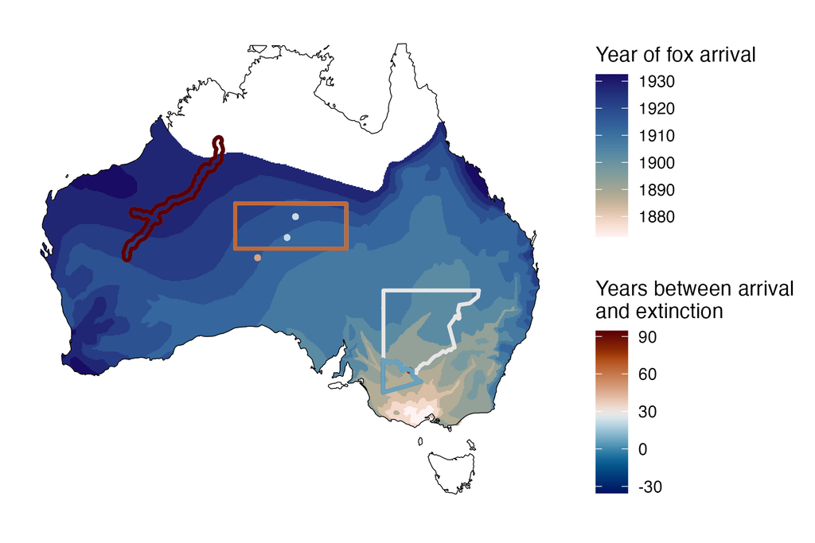

IUCN status: **Extinct**

Last seen: *Leporillus apicalis were last seen in 1933 in Norman Tindale, near Mt Crombie, south of the Musgrave Ranges in north-western South Australia (IUCN 2023)*

IUCN claim: *“Predation by feral cats is considered the main cause of extinction. The arrival of Red Foxes in range may have driven remnant subpopulations to extinction”*

### Studies in support

Lesser stick-nest rats were last confirmed at Mount Crombie 13-18 years after foxes arrived (Wallach and Lundgren 2025).

### Studies not in support

Lesser stick-nest rats were last confirmed in the Western Division of NSW, southern NT (three records), northwest Victoria and Euston 27-2, 30-15, 39-23, and 38-33 years before foxes arrived, respectively (Wallach and Lundgren 2025).

### Is the threat claim evidence-based?

Most extinction records pre-date the fox arrival records.

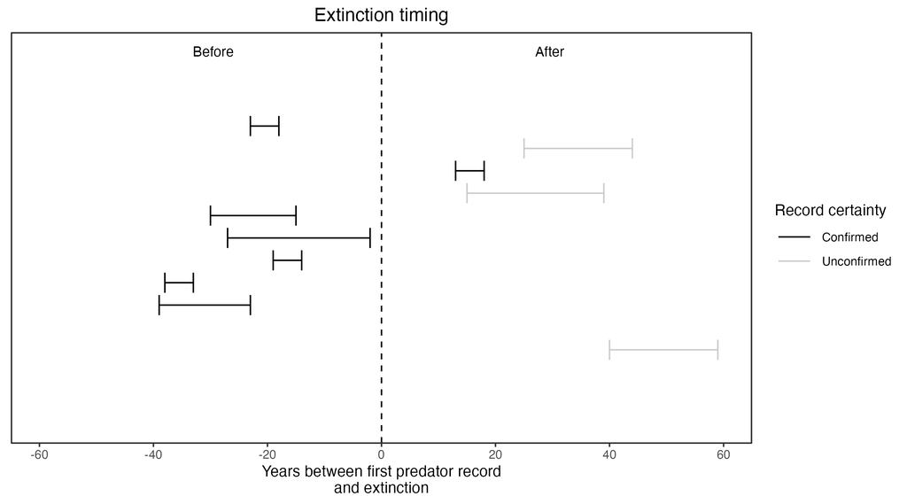

**Evidence linking *Leporillus apicalis* to foxes.** Last records of extirpated populations relative to earliest local records of foxes. Error bars show record uncertainty range. Predator arrival records were digitized from Fairfax 2019.

### References

Fairfax, Dispersal of the introduced red fox (Vulpes vulpes) across Australia. Biol. Invasions 21, 1259-1268 (2019).

IUCN Red List. https://www.iucnredlist.org/ Accessed June 2023

Wallach A.D., Lundgren E.J. (2025) Review of evidence that foxes and cats cause extinctions of Australia’s endemic mammals. BioScience. DOI: 10.1093/biosci/biaf046